# Homework #2 - Sample Solution

HH

2/1/2018

## Cars and mileage

In this homework we will use the `mpg` data set, you can access the data by loading the package `ggplot2` into your R session by executing the command `library(ggplot2)`. The `mpg` data includes information about fuel economy of popular car models for the years 1999 and 2008 as collected by the US Environmental Protection Agency.

Most exercises are from the ggplot2 book section 2.2.1. You might find it helpful for working on the homework to read through this section.

1. List five functions that you could use to get more information about the mpg dataset.

```
str, head, tail, summary, dim, names
```

2. Using the `ggplot2` package create a scatterplot of `hwy` and `cty` and describe the relationship. Why are there so few points visible? Use a geom that helps reduce the amount of overplotting in the scatterplot.

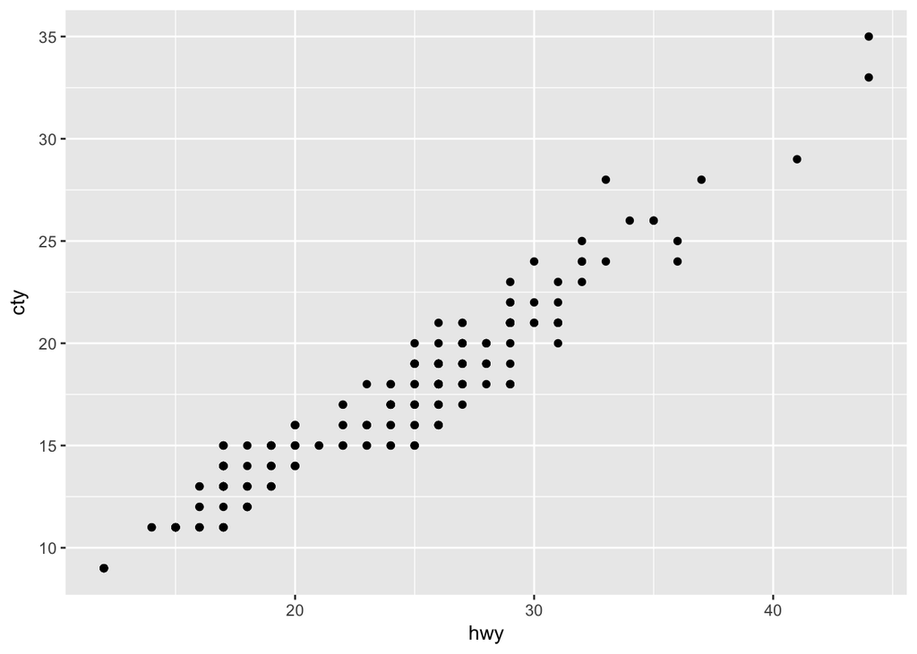

```r
library(ggplot2)
# there is a strong positive linear relationship between highway and city miles per gallon
ggplot(mpg, aes(x = hwy, y = cty)) + geom_point()
```

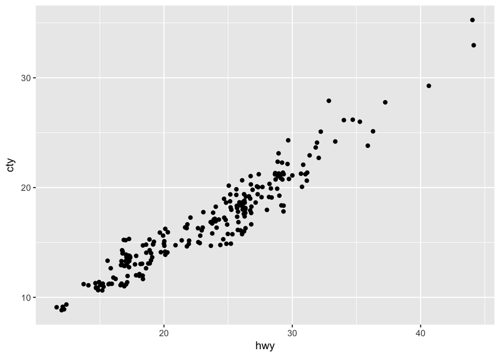

```r
# there is a lot of overplotting

# one solution: jitter
ggplot(mpg, aes(x = hwy, y = cty)) + geom_jitter()
```

3. Apart from the US, most countries use fuel consumption (fuel consumed over fixed distance) rather than fuel economy (distance traveled with fixed amount of fuel). How could you convert `cty` and `hwy` into the European standard of liter/100 km? Introduce corresponding variables into the `mpg` data.

```r
# 1 gallon = 3.78541 liters
# 1 mile = 1.60934 km
# therefore 1 mpg = 1.6/3.78 km per liter

mpg$cty_lkm <- 1/ (1.6/3.78 * mpg$cty) * 100
mpg$hwy_lkm <- 1/ (1.6/3.78 * mpg$hwy) * 100
```

4. Are cars in 2008 more fuel efficient than cars in 1999? Expand on your answer in (2) for a visual approach to this question. Note: you are not asked to find numeric answers. Instead, interpret plots.

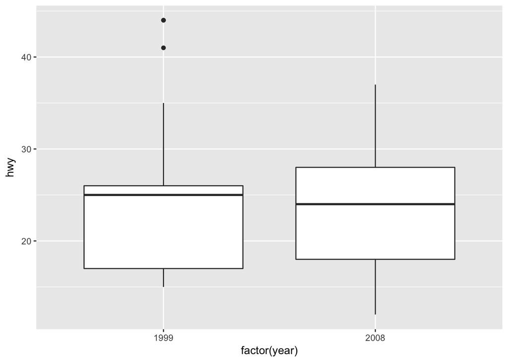

```r
# medians are a bit higher in 1999
ggplot(mpg, aes(x=factor(year), y=hwy)) + geom_boxplot()
```

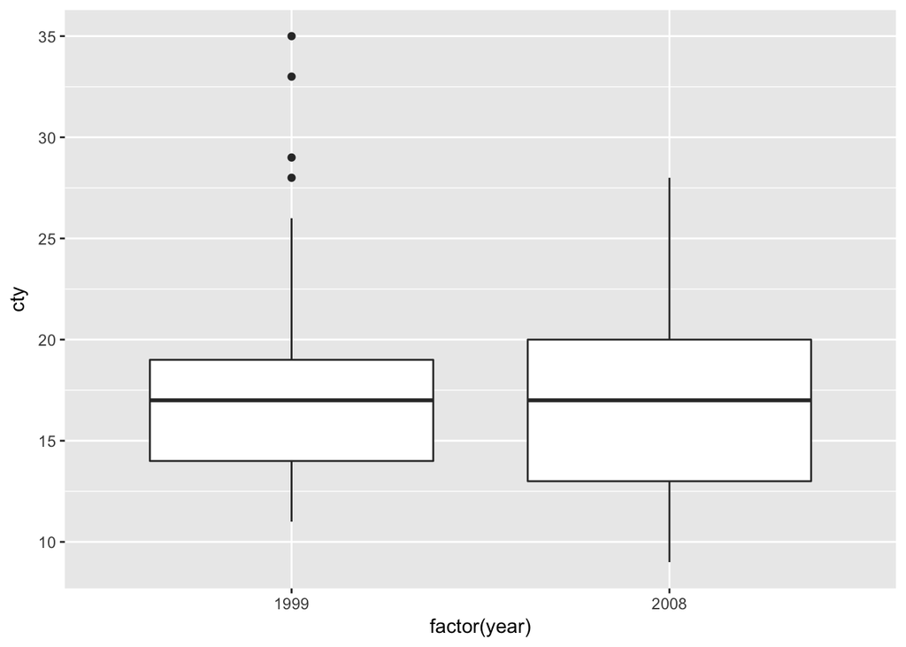

```r
# the very fuel efficient cars from 1999 have disappeared.
ggplot(mpg, aes(x=factor(year), y=cty)) + geom_boxplot()
```

```r
# seems like the trend should be different
```

6. Use the `ggplot2` package to create side-by-side boxplots of `cty` by `class`. Describe the relationship in 2-3 sentences. Change the label for the y-axis to ‘city miles per gallon’ (see `?ylab`).

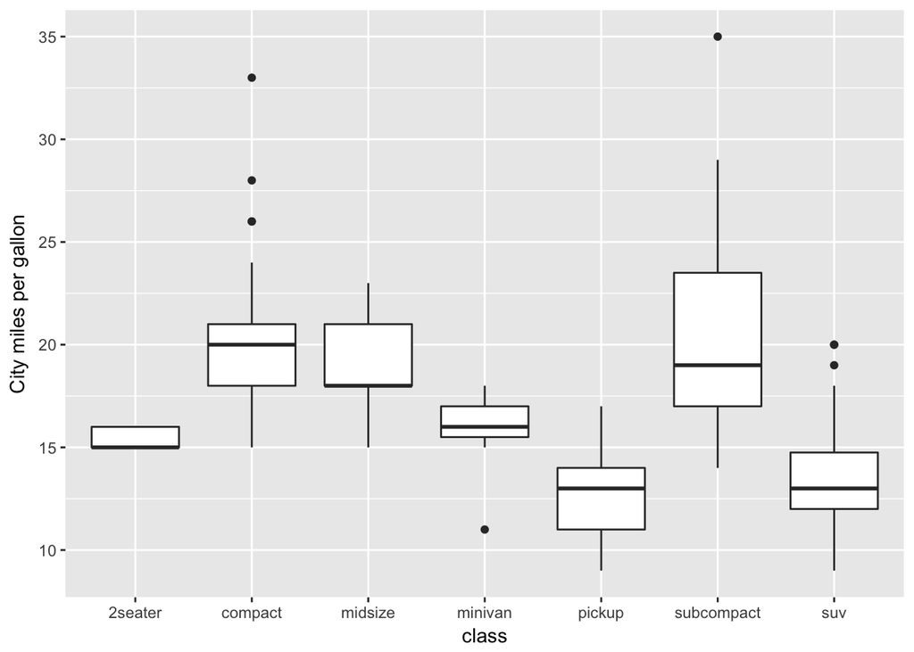

```r
ggplot(mpg, aes(x = class, y = cty))+geom_boxplot() +
  ylab("City miles per gallon")
```

compact and subcompact cars are on average the most fuel efficient cars. pickups and suvs are the least fuel efficient. one minivan is also very inefficient.